# odin

Rich FitzJohn

2025-02-07

# Single variable: Logistic growth

We’ll first start with a very simple model; logistic growth. We have one variable `N` which grows towards a carrying capacity `K`. The growth rate is `r` when `N` is very small (note that this equation can be easily solved analytically and it’s only included here for demonstration!)

```r
path_logistic <- system.file("examples/logistic.R", package = "odin")
```

```r
deriv(N) <- r * N * (1 - N / K)
initial(N) <- N0

N0 <- 1
K <- 100
r <- 0.5
```

The time derivatives are indicated by `deriv(N) <-`; the right hand side of this is the differential equation. Initial conditions are always given (future versions may make them optional) and can be in terms of variables. Note that the definition of declaration is not important; the derivative calculation references parameters `r` and `K` which have not been defined and the initial conditions reference `N0`.

**NOTE** while this *looks* like R (and must *parse* as R) it is not actually R code. Copying and pasting this code into an R session would throw an error

To compile this as a standalone model (not suitable for inclusion in a package) use `odin::odin`;

```r
generator <- odin::odin(path_logistic)
```

This returns an R6 generator that can be used to create an instance of the model:

```r
mod <- generator$new()
mod
```

```
## <odin_model>
##   Public:
##     contents: function ()
##     deriv: function (t, y)
##     initial: function (t)
##     initialize: function (..., user = list(...), use_dde = FALSE, unused_user_action = NULL)
##     ir: function ()
##     rhs: function (t, y)
##     run: function (t, y = NULL, ..., use_names = TRUE)
##     set_user: function (..., user = list(...), unused_user_action = NULL)
##     transform_variables: function (y)
##   Private:
##     cfuns: list
##     dll: logistic8d64270b
##     interpolate_t: NULL
##     n_out: 0
##     odin: environment
##     output_order: NULL
##     ptr: externalptr
##     registration: function ()
##     set_initial: function (t, y, use_dde)
##     update_metadata: function ()
##     use_dde: FALSE
##     user: NULL
##     variable_order: list
##     ynames: t N
```

The initial conditions:

```r
mod$init
```

[output not shown]

dN/dt evaluated at the time zero, with the initial conditions:

```r
mod$deriv(0, mod$initial(0))
```

```
## [1] 0.495
```

or with arbitrary conditions:

```r
mod$deriv(0, 50)
```

```
## [1] 12.5
```

To see the contents of all the variables, intermediates and parameters tracked by odin use `contents()`:

```r
mod$contents()
```

```
## $K
## [1] 100
##
## $N0
## [1] 1
##
## $initial_N
## [1] 1
##
## $r
## [1] 0.5
```

To run the model, provide a set of times:

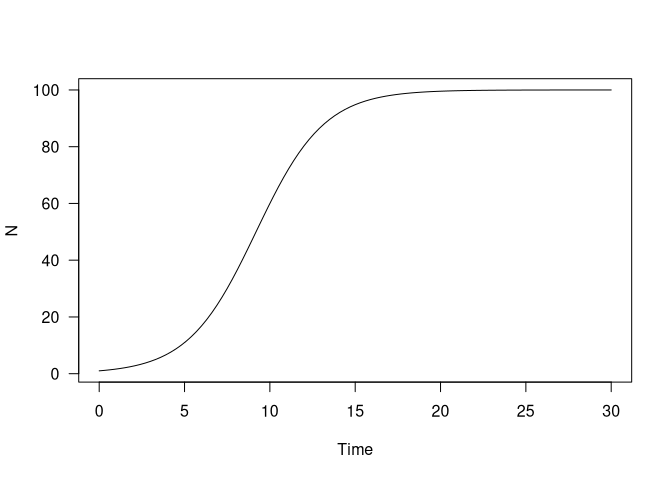

```r
tt <- seq(0, 30, length.out = 101)
y <- mod$run(tt)
plot(y, xlab = "Time", ylab = "N", las = 1, main = "")
```

While initial conditions are computed, you may pass in arbitrary initial conditions;

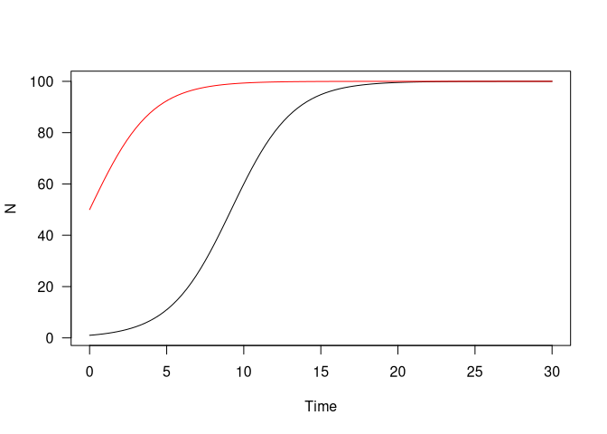

```r
y2 <- mod$run(tt, 50)
plot(y, xlab = "Time", ylab = "N", las = 1, main = "")
lines(y2, col = "red")
```

## Specifying parameters

The above is about the simplest possible useful model I could come up with. But it’s not that useful because all the parameters are hard coded into the model. Here’s a slightly tweaked version where the parameters may be specified at runtime:

```r
generator <- odin::odin({
  deriv(N) <- r * N * (1 - N / K)
  initial(N) <- N0

  N0 <- user(1)
  K <- user(100)
  r <- user()
})
```

when used as `user(1)` (as for `N` and `K`) it means we allow a user parameter called `N0` to be specified, but if omitted it has a default value of 1. When used as `user()` (as for `r`) it means that there is no default value and `r` **must** be provided.

Note this example takes the code of the model as its first argument. It can also be specified as text, but the form above should be nicer to write than text, especially in editors with support for things like autocompletion.

Because `r` is required, it is an error to initialise the model without any parameters:

```r
generator$new()
```

```
## Error in self$set_user(user = user, unused_user_action = unused_user_action): Expected a value for 'r'
```

Providing `r`:

```r
mod <- generator$new(r = 1)
```

The model contains the set value of r

```r
mod$contents()$r
```

```
## [1] 1
```

Running the model shows the effect of doubling the growth rate:

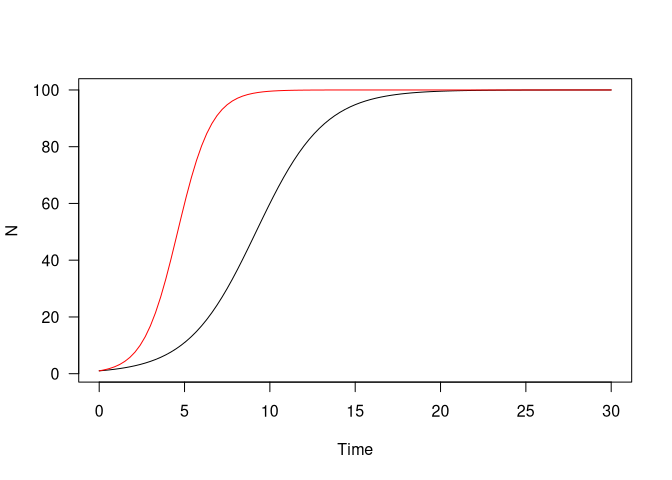

```r
y3 <- mod$run(tt)
plot(y, xlab = "Time", ylab = "N", las = 1, main = "")
lines(y3, col = "red")
```

Once created a model can have the parameters re-set:

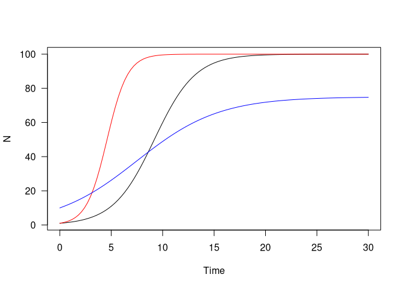

```r
mod$set_user(r = 0.25, K = 75, N0 = 10)
y4 <- mod$run(tt)
plot(y, xlab = "Time", ylab = "N", las = 1, main = "")
lines(y3, col = "red")
lines(y4, col = "blue")
```

# More than one variable: the Lorenz attractor

Once more than one variable is involved, there is a bit more book-keeping to take care of.

```r
path_lorenz <- system.file("examples/lorenz.R", package = "odin")
```

The Lorenz attractor is a set of coupled ODEs that displays chaotic behaviour. It was found by reducing a set of equations describing atmospheric convection in the 1960s. Mostly I just think it looks pretty.

```r
deriv(y1) <- sigma * (y2 - y1)
deriv(y2) <- R * y1 - y2 - y1 * y3
deriv(y3) <- -b * y3 + y1 * y2

initial(y1) <- 10.0
initial(y2) <- 1.0
initial(y3) <- 1.0

## These are the classical parameters:
sigma <- 10
R <- 28
b <-  8 / 3
```

The system is not chaotic with all parameters. The initial conditions are fairly arbitrary here as the system will settle into its characteristic shape from most points (though with completely different realisations).

Building the generator, and from that a system, is the same as the above:

```r
generator <- odin::odin(path_lorenz)
mod <- generator$new()
```

Because of the rapid changes that characterise this model, we’ll take a *lot* of samples.

```r
tt <- seq(0, 100, length.out = 20000)
system.time(y <- mod$run(tt))
```

```
##    user  system elapsed
##   0.005   0.000   0.006
```

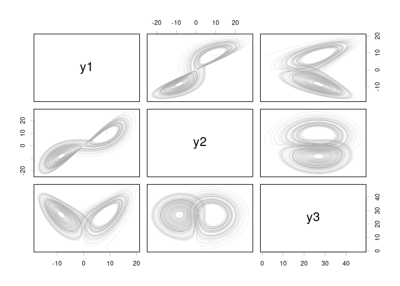

```r
pairs(y[, -1L], panel = lines, lwd = .2, col = "#00000055")
```

# Delay models

Models with lags and delays represent a challenge in solving and representing the system, see [this wikipedia article](https://en.wikipedia.org/wiki/Delay_differential_equation) for some of the issues. In the general case this gives a set of partial differential equations, which are much harder to solve generally than ordinary differential equations.

Like Berkeley Madonna, `odin` allows solving equations with lags, using the machinery available in `deSolve`. One can specify a lag in a state variable or an expression. The lag times can also be variables.

```r
gen <- odin::odin({
  ylag <- delay(y, tau)
  initial(y) <- 0.5
  deriv(y) <- 0.2 * ylag * 1 / (1 + ylag^10) - 0.1 * y
  tau <- user(10)
  output(ylag) <- ylag
})
dde <- gen$new()
```

The first line here

```r
ylag <- delay(y, tau)
```

specifies the delay; it says that `ylag` should be equal to `y` from `tau` ago. Or; `ylag(t) = y(t - tau)`.

`delay` expressions must be the only expressions on the rhs of an assignment. The first argument can be a single variable (like here) or it can be an expression.

Running the model will automatically use the `deSolve::dede` function.

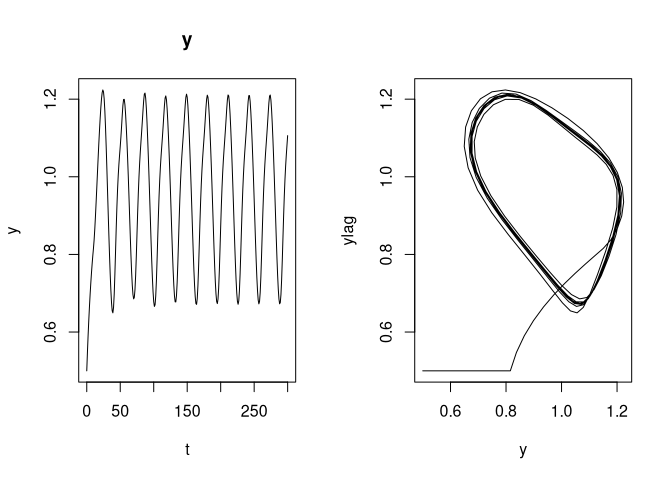

```r
t <- seq(0, 300, length.out = 301)
y1 <- dde$run(t)
plot(y1, ylab = "y", mfrow = c(1, 2), which = 1)
plot(y1[, -1L], xlab = "y", ylab = "ylag", mfrow = NULL, type = "l")
```

Increasing the lag time creates much more complicated trajectories:

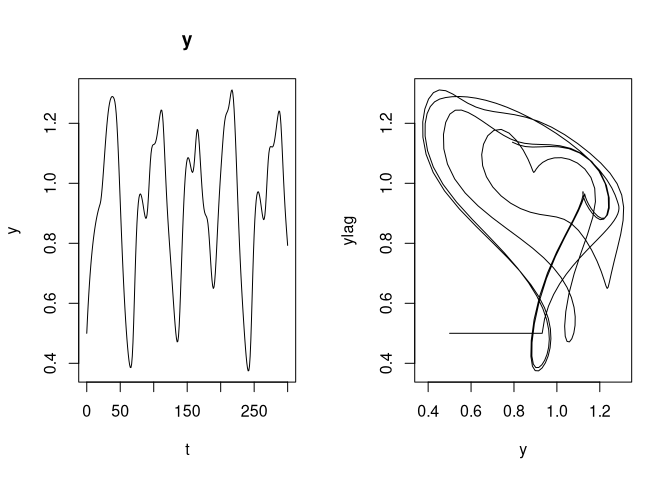

```r
dde$set_user(tau = 20)
y2 <- dde$run(t)
plot(y2, ylab = "y", mfrow = c(1, 2), which = 1)
plot(y2[, -1L], xlab = "y", ylab = "ylag", mfrow = NULL, type = "l")
```

# Arrays

Much of the above, especially the non-delay equations, can be expressed easily in deSolve. Even where the target functions are written in R they will tend to be fast enough to solve (unless strongly non-linear) so that the gains for writing out in C become small. `odin` was really designed for cases where the variables involved are *arrays*, used here to mean vectors, matrices or 3d matrices.

There are quite a few restrictions on how arrays are used, how indexing works, etc. Some of the current implementation requires creation of intermediate variables to make everything work (and naming things is one of the [two hard problems in computer science](https://martinfowler.com/bliki/TwoHardThings.html). Hopefully in future versions some of these restrictions can be relaxed, so [file issues](https://github.com/mrc-ide/odin/issues) if you find yourself writing boilerplate code that could be replaced by more intelligent generation.

## Generalised Lotka-Volterra model

This example comes from the [wikipedia page](https://en.wikipedia.org/wiki/Competitive_Lotka%E2%80%93Volterra_equations#4-dimensional_example), in turn from [Vano et al 2006](https://sprott.physics.wisc.edu/pubs/paper288.pdf). This model has four non-linear differential equations that have chaotic behaviour in fairly low dimension.

```r
gen <- odin::odin({
  deriv(y[]) <- r[i] * y[i] * (1 - sum(ay[i, ]))
  initial(y[]) <- y0[i]

  y0[] <- user()
  r[] <- user()
  a[, ] <- user()
  ay[, ] <- a[i, j] * y[j]

  dim(r) <- user()
  n_spp <- length(r)

  dim(y) <- n_spp
  dim(y0) <- n_spp
  dim(a) <- c(n_spp, n_spp)
  dim(ay) <- c(n_spp, n_spp)

  config(base) <- "lv4"
})
```

These are the parameters from the wikipedia article, with `y0` being close to the (unstable) equilibrium.

```r
pars <- list(r = c(1.00, 0.72, 1.53, 1.27),
             a = rbind(c(1.00, 1.09, 1.52, 0.00),
                       c(0.00, 1.00, 0.44, 1.36),
                       c(2.33, 0.00, 1.00, 0.47),
                       c(1.21, 0.51, 0.35, 1.00)),
             y0 = c(0.3013, 0.4586, 0.1307, 0.3557))
```

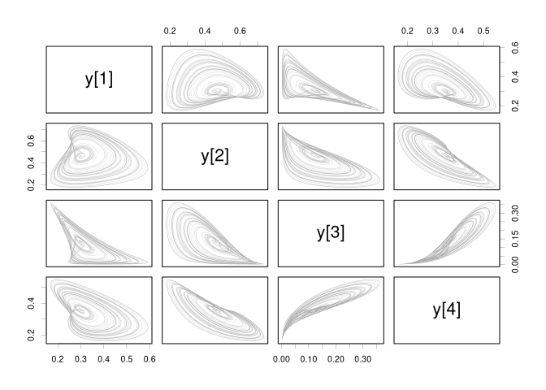

```r
mod <- gen$new(user = pars)

t <- seq(0, 2000, length.out = 10001)
y <- mod$run(t)
pairs(y[, -1], panel = lines, col = "#00000055", lwd = 0.2)
```